# batman uscript code

# 6 Comparison of the highest risk species (point estimates)

```r
allscores = data.frame(
  actual=name.data$Conservation.category.numeric,
  medianimputedGLS=apply(imputedGLS.fitted,1,median)
)

ord = order(allscores$medianimputedGLS,decreasing=T)

topEstimates = (allscores[ord,])
head(topEstimates,20)
```

```
##                           actual medianimputedGLS
## Pteropus_melanopogon           4         3.466283
## Pteropus_livingstonii          5         3.430934
## Pteralopex_flanneryi           5         3.357969
## Acerodon_jubatus               4         3.349146
## Pteropus_howensis              5         3.322518
## Pteropus_speciosus            NA         3.255126
## Pteropus_neohibernicus         1         3.253482
## Pteropus_conspicillatus        4         3.252830
## Pteropus_voeltzkowi            3         3.244977
## Alionycteris_paucidentata      1         3.186832
## Rousettus_linduensis          NA         3.184696
## Pteropus_caniceps              3         3.158347
## Pteropus_mariannus             4         3.140869
## Pteropus_vampyrus              4         3.133537
## Pteralopex_pulchra             5         3.131624
## Pteropus_rufus                 3         3.057882
## Rhinolophus_willardi           4         3.026402
## Nyctophilus_microdon           1         3.015391
## Pteropus_ocularis              3         3.014380
## Nyctimene_minutus              3         2.976280
```

## 6.1 Boxplots of highest GLS estimates (for missing Status)

```r
require(reshape2)
```

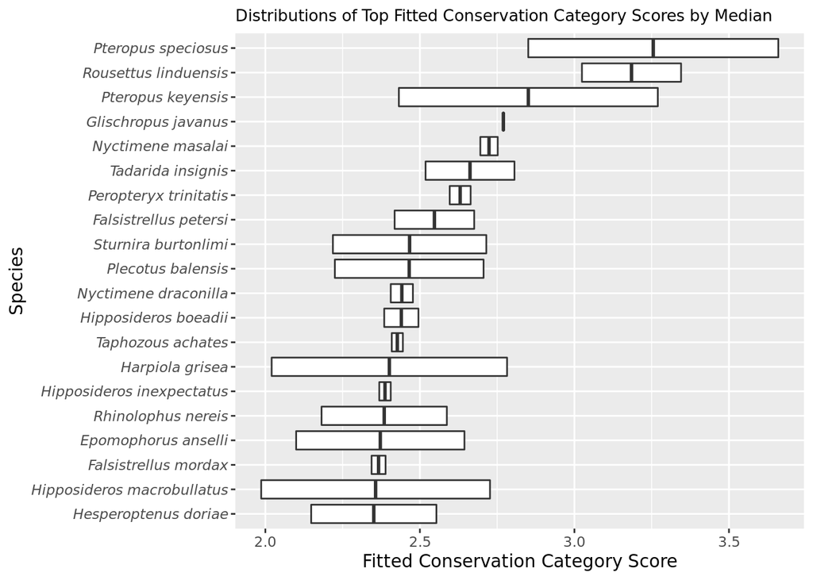

```r
top=1:20

missing = is.na(allscores$actual)

missingScores = allscores[missing,]
missingImputedGLS.fitted = imputedGLS.fitted[missing,]




ord = order(missingScores$medianimputedGLS,decreasing=T)
topEstimates = (missingScores[ord,])
ordtop = rev(ord[top])

imputeddf = melt(missingImputedGLS.fitted[ordtop,],varnames=c("Species","dataset"))
imputeddf[,2]="imputedgls"

imputeddf$dataset=as.factor(imputeddf$dataset)


spacedSpecies = sapply(strsplit(as.character(imputeddf$Species),"_"),paste,collapse=" ")
imputeddf=data.frame(imputeddf,spacedSpecies=spacedSpecies)

#head(imputeddf)

ggplot(imputeddf,aes(x=reorder(spacedSpecies,value,FUN=median),y=value))+
  geom_boxplot()+
  ylab("Fitted Conservation Category Score")+ggtitle("Distributions of Top Fitted Conservation Category Scores by Median")+theme(plot.title = element_text(size = 10))+xlab("Species")+
  theme(axis.text.y = element_text(face = "italic"))+
  coord_flip()
```

# 7 Conservation Category Scores by species

```r
imputedEstimates=data.frame(
  glsestimate=rowMeans(imputedGLS.fitted),
  actual = as.factor(name.data$Conservation.category.numeric),
  row.names=Species)

## habitat, diet, island mainland, imn temp coldest month, area.
ordofvars = match(row.names(imputedEstimates),rownames(modelVariables))
head(ordofvars)
```

```
## [1] 1 2 3 4 5 6
```

```r
imputedEstimates2 = data.frame(imputedEstimates,modelVariables[ordofvars,])
```

### 7.0.1 Highest Scores

```r
imputedEstimates2[order(imputedEstimates2$glsestimate,decreasing=T)[1:40],]
```

```
##                           glsestimate actual Conservation.category.numeric
## Pteropus_melanopogon         3.466283      4                             4
## Pteropus_livingstonii        3.430934      5                             5
## Pteralopex_flanneryi         3.357969      5                             5
## Acerodon_jubatus             3.349146      4                             4
## Pteropus_howensis            3.322518      5                             5
## Pteropus_speciosus           3.255126   <NA>                            NA
## Pteropus_neohibernicus       3.253482      1                             1
## Pteropus_conspicillatus      3.252830      4                             4
## Pteropus_voeltzkowi          3.244977      3                             3
## Alionycteris_paucidentata    3.186832      1                             1
## Rousettus_linduensis         3.184696   <NA>                            NA
## Pteropus_caniceps            3.158347      3                             3
## Pteropus_mariannus           3.140869      4                             4
## Pteropus_vampyrus            3.133537      4                             4
## Pteralopex_pulchra           3.131624      5                             5
## Pteropus_rufus               3.057882      3                             3
## Rhinolophus_willardi         3.026402      4                             4
## Nyctophilus_microdon         3.015391      1                             1
## Pteropus_ocularis            3.014380      3                             3
## Nyctimene_minutus            2.976280      3                             3
## Hypsugo_lanzai               2.960243      4                             4
## Pteropus_rodricensis         2.930354      4                             4
## Pteropus_niger               2.925803      4                             4
## Pteropus_griseus             2.923908      3                             3
## Pteropus_aldabrensis         2.900750      4                             4
## Pteropus_pelewensis          2.899536      3                             3
## Kerivoula_agnella            2.899233      4                             4
## Pteropus_pohlei              2.898933      3                             3
## Pteropus_pselaphon           2.872973      4                             4
## Neoromicia_malagasyensis     2.860600      3                             3
## Pteropus_keyensis            2.850877   <NA>                            NA
## Phyllonycteris_aphylla       2.841767      5                             5
## Dyacopterus_rickarti         2.832508      4                             4
## Plecotus_sacrimontis         2.830856      1                             1
## Rhinolophus_madurensis       2.811088      3                             3
## Neopteryx_frosti             2.798695      4                             4
## Pteropus_rennelli            2.780093      4                             4
## Pteropus_aruensis            2.776434      5                             5
## Glischropus_javanus          2.770106   <NA>                            NA
```

[output cut: 191 more lines]

```
## Pteropus_pelewensis       6.599564e-06
## Kerivoula_agnella         3.220914e-03
## Pteropus_pohlei           2.597564e-03
## Pteropus_pselaphon        7.181015e-05
## Neoromicia_malagasyensis  7.033956e-03
## Pteropus_keyensis         1.071177e-03
## Phyllonycteris_aphylla    2.151860e-04
## Dyacopterus_rickarti      2.926565e-03
## Plecotus_sacrimontis      2.067135e-01
## Rhinolophus_madurensis    4.927498e-03
## Neopteryx_frosti          6.744001e-03
## Pteropus_rennelli         5.441029e-04
## Pteropus_aruensis         7.030018e-03
## Glischropus_javanus       6.608294e-04
## Pteralopex_atrata         5.153553e-03
```

### 7.0.2 Lowest Scores

```r
imputedEstimates2[order(imputedEstimates2$glsestimate,decreasing=F)[1:40],]
```

```
##                            glsestimate actual Conservation.category.numeric
## Desmodus_rotundus         -0.573779510      1                             1
## Vespertilio_murinus       -0.423940451      1                             1
## Anoura_latidens           -0.285705237      1                             1
## Molossus_molossus         -0.260054308      1                             1
## Macroglossus_sobrinus     -0.065505141      1                             1
## Rhinolophus_ferrumequinum -0.063046014      1                             1
## Saccopteryx_bilineata     -0.037334475      1                             1
## Phyllostomus_discolor     -0.029902886      1                             1
## Myotis_daubentonii        -0.021786602      1                             1
## Nyctinomops_macrotis      -0.015621447      1                             1
## Lionycteris_spurrelli     -0.007014505      1                             1
## Choeroniscus_godmani       0.012418922      1                             1
## Eptesicus_fuscus           0.015322491      1                             1
## Scleronycteris_ega         0.016932580   <NA>                            NA
## Lichonycteris_obscura      0.022976545      1                             1
## Eptesicus_brasiliensis     0.024582721      1                             1
## Eumops_perotis             0.025440640      1                             1
## Hylonycteris_underwoodi    0.034613115      1                             1
## Lasiurus_blossevillii      0.037809693      1                             1
## Anoura_geoffroyi           0.043792562      1                             1
## Myotis_nigricans           0.095272975      1                             1
## Anoura_caudifer            0.111891270      1                             1
## Nycteris_macrotis          0.112453271      1                             1
## Lasiurus_ega               0.127253856      1                             1
## Eptesicus_nilssonii        0.132594277      1                             1
## Glossophaga_leachii        0.132854465      1                             1
## Myotis_volans              0.137621215      1                             1
## Nyctinomops_aurispinosus   0.145185035      1                             1
## Artibeus_lituratus         0.146517714      1                             1
## Tadarida_teniotis          0.163886295      1                             1
## Megaloglossus_woermanni    0.173370774      1                             1
## Pipistrellus_tenuis        0.191181345      1                             1
## Myotis_atacamensis         0.191467946      4                             4
## Glossophaga_commissarisi   0.192771800      1                             1
## Diclidurus_albus           0.198717959      1                             1
## Nycteris_hispida           0.202568760      1                             1
## Micronycteris_microtis     0.210975774      1                             1
## Pipistrellus_kuhlii        0.213249342      1                             1
## Lonchophylla_thomasi       0.229948907      1                             1
```

[output cut: 191 more lines]

```
## Glossophaga_leachii        0.4807959
## Myotis_volans              4.7117355
## Nyctinomops_aurispinosus   3.5680854
## Artibeus_lituratus        14.2347564
## Tadarida_teniotis          3.8975769
## Megaloglossus_woermanni    3.1200826
## Pipistrellus_tenuis        7.8483224
## Myotis_atacamensis         0.2536023
## Glossophaga_commissarisi   3.7162207
## Diclidurus_albus          12.4967275
## Nycteris_hispida          11.5052783
## Micronycteris_microtis     4.3952768
## Pipistrellus_kuhlii       10.9059603
## Lonchophylla_thomasi       8.3830716
## Lasiurus_cinereus         21.0774297
```

# 8 Summary info about missing data

```r
propmissing=apply(modelVariables,2,is.na) |> colMeans()
kable(as.data.frame(propmissing))
```

|  | propmissing |
| --- | --- |
| Conservation.category.numeric | 0.1479347 |
| collapsed.Habitats | 0.0441883 |
| Altitude.mid.m | 0.4409222 |
| Altitude.range.m | 0.4409222 |
| Max.temp.warmest.month | 0.1181556 |
| Simple.Primary.diet | 0.0000000 |
| weight.avg.g | 0.1277618 |
| Island.mainland.classification | 0.0288184 |
| Annual.precip. | 0.1181556 |
| Area.mkm | 0.0000000 |

```r
missingPredictors = !complete.cases(modelVariables[,-1])
missingResponse   = modelVariables[,1] |> is.na()

(missingTable = table(missingPredictors,missingResponse)/length(missingPredictors)|> round(2))
```

```
##                  missingResponse
## missingPredictors      FALSE       TRUE
##             FALSE 0.38424592 0.03458213
##             TRUE  0.46781940 0.11335255
```

```r
incompletePredictors = missingTable[2,]|>sum()|> (`*`)(100)|>round(2)
incompleteTotally = (1-missingTable[1,1])|>(`*`)(100)|>round(2)
```

58.12% of the predictor data contains at least one missing value and 61.58% of the species information (predictor data and conservation status) contains at least one missing value.

# 9 Model variables

The summary of the model estimates (not including the standard errors) are shown below are shown below.

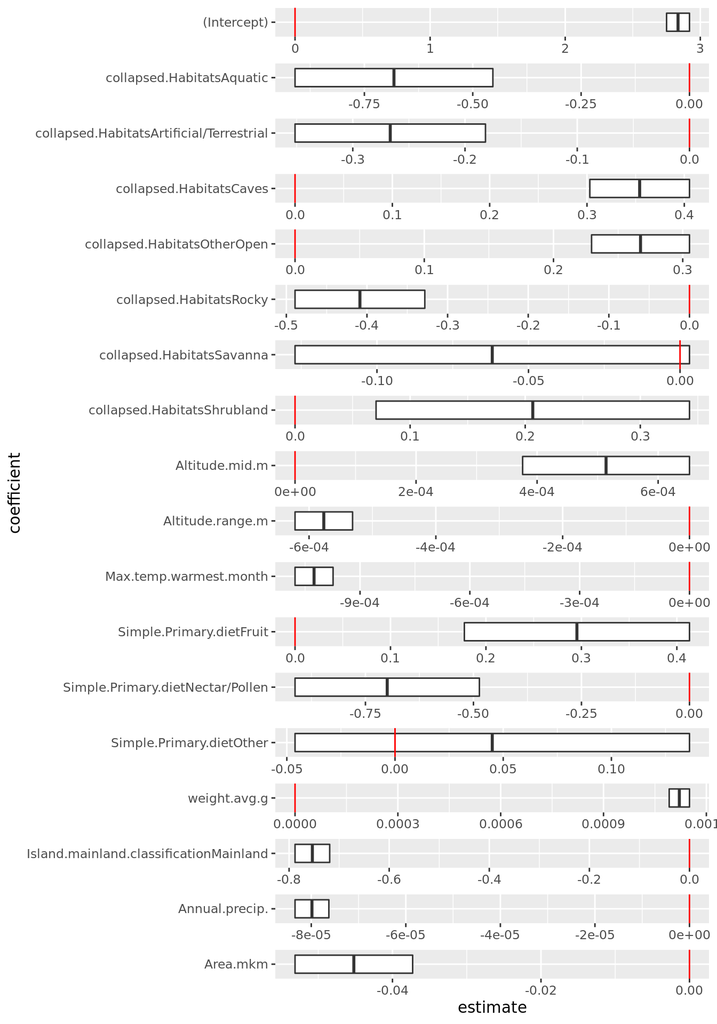

```r
summaries = lapply(imputedModelsGLS,summary)


allEstimates = sapply(summaries,function(s) s$coefficients)

estimatesdf = reshape2::melt(allEstimates,value.name = c("estimate"),varnames=c("coefficient","imputationNumber"))

ggplot(estimatesdf,aes(x=coefficient,y=estimate))+
  geom_boxplot()+geom_hline(yintercept=0,color="red")+
  facet_wrap(coefficient~.,scales="free",ncol=1)+
   theme(strip.text.x = element_blank())+coord_flip()
```

# 10 Frequentist summary tables

```r
avgEstimate = data.frame(avgEstimate=apply(allEstimates,1,mean))

ttables = lapply(summaries,function(i)i$tTable)


stdErrs = sapply(ttables,function(i)i[,2])

#pool the standard error estimates

avgstderr = rowMeans(stdErrs)
vw = rowMeans(stdErrs^2)  #variance within
vb=  apply(stdErrs,1,var) #variance betwn (sample var)
vtot = vw+(1+1/(nimp))*vb

stdpooled = sqrt(vtot)

avgEstimate=apply(allEstimates,1,mean)

siglevel = 0.05

crit = -qnorm(siglevel/2)


lb = avgEstimate - crit*stdpooled
ub = avgEstimate + crit*stdpooled

teststat = avgEstimate/stdpooled

pval = 2*pnorm(-abs(teststat))

flags = c("****", "***", "**", "*", "")[findInterval(pval,c(0, 0.0001, 0.001, 0.01, 0.05, 1))]
```

## 10.1 for slopes and significance

```r
kable(data.frame(avgEstimate,stdpooled,pval,flags))
```

|  | avgEstimate | stdpooled | pval | flags |
| --- | --- | --- | --- | --- |
| (Intercept) | 2.8351670 | 1.5569732 | 0.0686148 |  |
| collapsed.HabitatsAquatic | -0.6817677 | 0.3168424 | 0.0314165 | * |
| collapsed.HabitatsArtificial/Terrestrial | -0.2666144 | 0.0842856 | 0.0015603 | ** |
| collapsed.HabitatsCaves | 0.3541343 | 0.1023976 | 0.0005433 | *** |
| collapsed.HabitatsOtherOpen | 0.2673462 | 0.2886937 | 0.3544175 |  |
| collapsed.HabitatsRocky | -0.4087435 | 0.1926625 | 0.0338754 | * |
| collapsed.HabitatsSavanna | -0.0619582 | 0.1280414 | 0.6284625 |  |
| collapsed.HabitatsShrubland | 0.2065759 | 0.1591765 | 0.1943632 |  |
| Altitude.mid.m | 0.0005140 | 0.0000815 | 0.0000000 | **** |
| Altitude.range.m | -0.0005767 | 0.0000519 | 0.0000000 | **** |
| Max.temp.warmest.month | -0.0010256 | 0.0008287 | 0.2158671 |  |
| Simple.Primary.dietFruit | 0.2953101 | 0.5351678 | 0.5810796 |  |
| Simple.Primary.dietNectar/Pollen | -0.6995919 | 0.5628250 | 0.2138675 |  |
| Simple.Primary.dietOther | 0.0449377 | 0.3882936 | 0.9078655 |  |
| weight.avg.g | 0.0011212 | 0.0002890 | 0.0001047 | *** |
| Island.mainland.classificationMainland | -0.7535042 | 0.0953932 | 0.0000000 | **** |
| Annual.precip. | -0.0000799 | 0.0000356 | 0.0247543 | * |
| Area.mkm | -0.0452026 | 0.0103758 | 0.0000132 | **** |

## 10.2 for intervals

```r
sig = (sign(lb)==sign(ub))|>ifelse(" *","")
kable(data.frame(estimate=avgEstimate,lb,ub,sig ))
```

|  | estimate | lb | ub | sig |
| --- | --- | --- | --- | --- |
| (Intercept) | 2.8351670 | -0.2164444 | 5.8867784 |  |
| collapsed.HabitatsAquatic | -0.6817677 | -1.3027675 | -0.0607680 | * |
| collapsed.HabitatsArtificial/Terrestrial | -0.2666144 | -0.4318112 | -0.1014176 | * |
| collapsed.HabitatsCaves | 0.3541343 | 0.1534387 | 0.5548300 | * |
| collapsed.HabitatsOtherOpen | 0.2673462 | -0.2984831 | 0.8331756 |  |
| collapsed.HabitatsRocky | -0.4087435 | -0.7863550 | -0.0311320 | * |
| collapsed.HabitatsSavanna | -0.0619582 | -0.3129148 | 0.1889984 |  |
| collapsed.HabitatsShrubland | 0.2065759 | -0.1054043 | 0.5185560 |  |
| Altitude.mid.m | 0.0005140 | 0.0003542 | 0.0006737 | * |
| Altitude.range.m | -0.0005767 | -0.0006784 | -0.0004750 | * |
| Max.temp.warmest.month | -0.0010256 | -0.0026499 | 0.0005986 |  |
| Simple.Primary.dietFruit | 0.2953101 | -0.7535995 | 1.3442196 |  |
| Simple.Primary.dietNectar/Pollen | -0.6995919 | -1.8027087 | 0.4035248 |  |
| Simple.Primary.dietOther | 0.0449377 | -0.7161037 | 0.8059791 |  |
| weight.avg.g | 0.0011212 | 0.0005547 | 0.0016876 | * |
| Island.mainland.classificationMainland | -0.7535042 | -0.9404714 | -0.5665370 | * |
| Annual.precip. | -0.0000799 | -0.0001496 | -0.0000101 | * |
| Area.mkm | -0.0452026 | -0.0655389 | -0.0248664 | * |

## 10.3 Interpreting the numbers

The significance of the slopes are all with respect to the **reference** variables.

# 11 Visual summaries

Looking at the visual summaries, it’s not surprising that only the variables with variability in score come up significant.

## 11.1 Category by Habitat

```r
subsettable = with(modelVariables,data.frame(collapsed.Habitats,Conservation.category.numeric))
subsettable=subsettable[complete.cases(subsettable),]
tab = addmargins(table(subsettable))

kable(tab)
```

|  | 1 | 2 | 3 | 4 | 5 | Sum |
| --- | --- | --- | --- | --- | --- | --- |
| Aquatic | 13 | 0 | 1 | 0 | 0 | 14 |
| Artificial/Terrestrial | 129 | 14 | 16 | 11 | 2 | 172 |
| Caves | 74 | 11 | 10 | 19 | 3 | 117 |
| Forest | 300 | 39 | 57 | 29 | 10 | 435 |
| OtherOpen | 11 | 0 | 0 | 3 | 0 | 14 |
| Rocky | 18 | 3 | 2 | 2 | 0 | 25 |
| Savanna | 47 | 1 | 0 | 3 | 0 | 51 |
| Shrubland | 35 | 3 | 2 | 3 | 1 | 44 |
| Sum | 627 | 71 | 88 | 70 | 16 | 872 |

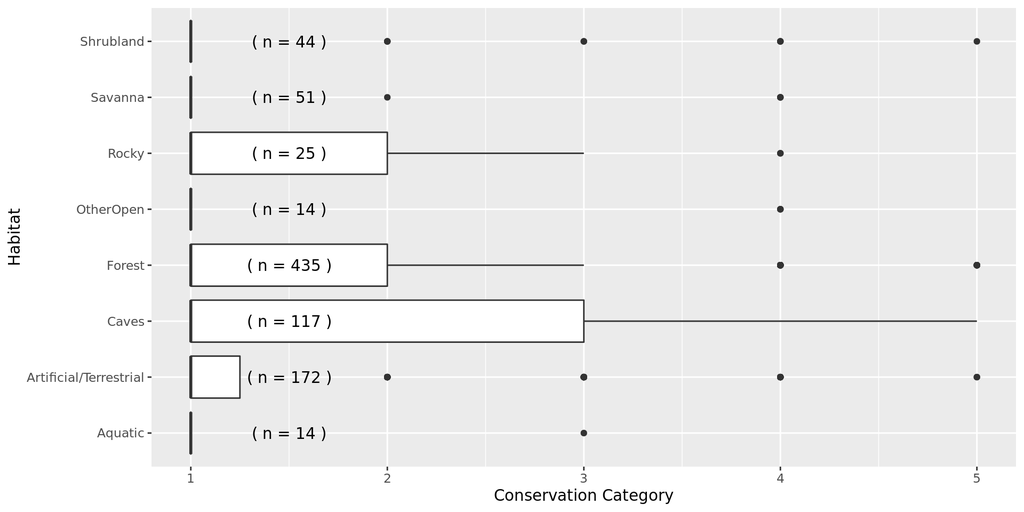

```r
p=nrow(tab)-1
habitats = rownames(tab);habitats=habitats[1:p]#removes "sum"
sizes = paste( "( n =",tab[1:p,ncol(tab)],")")

size.df = data.frame(
  sizes=sizes,
  x=seq_len(p),
  y=rep(1.5,p)
)


ggplot(subsettable,aes(x=collapsed.Habitats,y=Conservation.category.numeric))+
  geom_boxplot()+xlab("Habitat")+ylab("Conservation Category")+
  geom_text(data=size.df,aes(label=sizes,y=y,x=x))+
  coord_flip()
```

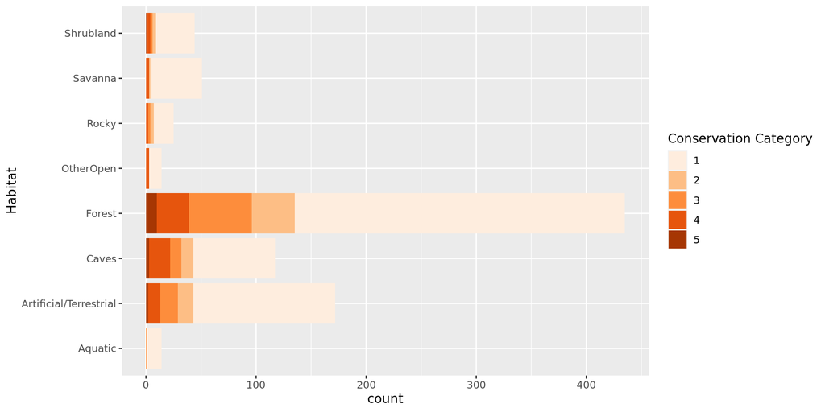

```r
#boxplot(modelVariables$Conservation.category.numeric~modelVariables$Habitats)

ggplot(subsettable,aes(x=collapsed.Habitats))+
  geom_bar(aes(fill=factor(Conservation.category.numeric)))+
  labs(fill="Conservation Category")+
  scale_fill_brewer(palette=7)+
  xlab("Habitat")+
  coord_flip()
```

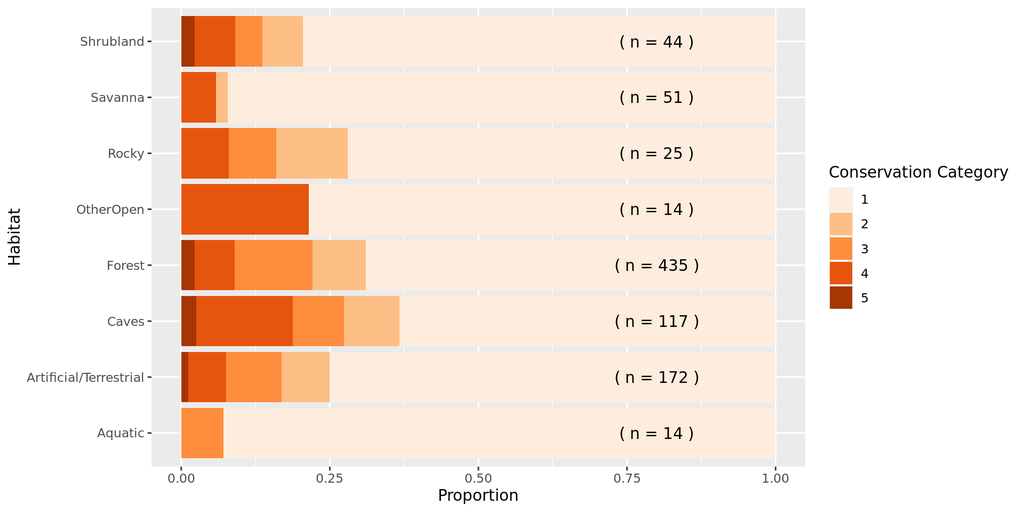

```r
size.df$x = habitats
size.df$y=0.8

ggplot(subsettable,aes(x=collapsed.Habitats))+
  geom_bar(aes(fill=factor(Conservation.category.numeric)),position="fill")+
  scale_fill_brewer(palette=7)+xlab("Habitat")+ylab("Known Conservation Category")+
  labs(fill="Conservation Category")+
  ylab("Proportion")+
  xlab("Habitat")+
  geom_text(data=size.df,aes(label=sizes,y=y,x=x))+
  coord_flip()
```

## 11.2 Category by Diet

```r
subsettable = with(modelVariables,data.frame(Simple.Primary.diet,Conservation.category.numeric))
subsettable=subsettable[complete.cases(subsettable),]
tab = addmargins(table(subsettable))

kable(tab)
```

|  | 1 | 2 | 3 | 4 | 5 | Sum |
| --- | --- | --- | --- | --- | --- | --- |
| Fruit | 125 | 18 | 29 | 26 | 9 | 207 |
| Insects | 452 | 50 | 52 | 42 | 9 | 605 |
| Nectar/Pollen | 37 | 5 | 5 | 4 | 0 | 51 |
| Other | 17 | 2 | 3 | 2 | 0 | 24 |
| Sum | 631 | 75 | 89 | 74 | 18 | 887 |

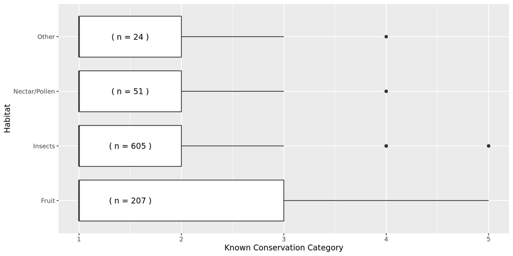

```r
p=nrow(tab)-1
diets = rownames(tab);diets=diets[1:p]#removes "sum"
sizes = paste( "( n =",tab[1:p,ncol(tab)],")")

size.df = data.frame(
  sizes=sizes,
  x=seq_len(p),
  y=rep(1.5,p)
)


ggplot(subsettable,aes(x=Simple.Primary.diet,y=Conservation.category.numeric))+
  geom_boxplot()+xlab("Habitat")+ylab("Known Conservation Category")+
  geom_text(data=size.df,aes(label=sizes,y=y,x=x))+
  coord_flip()
```

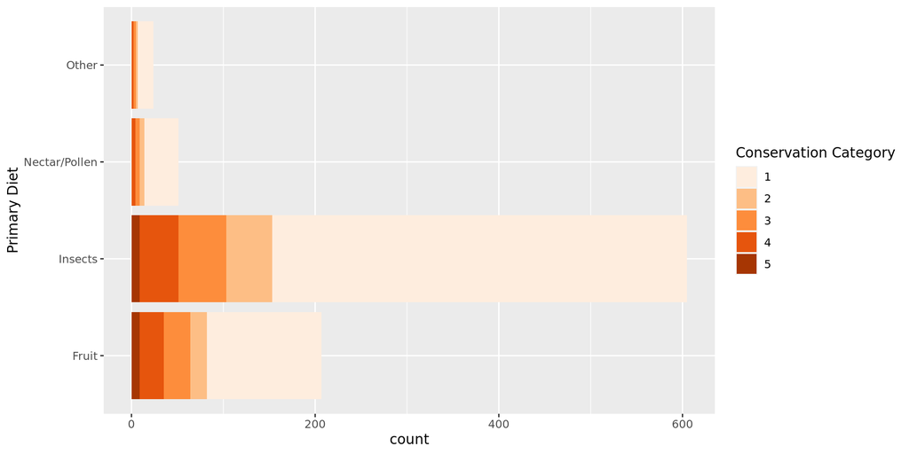

```r
#boxplot(modelVariables$Conservation.category.numeric~modelVariables$Habitats)

ggplot(subsettable,aes(x=Simple.Primary.diet))+
  geom_bar(aes(fill=factor(Conservation.category.numeric)))+
  scale_fill_brewer(palette=7)+
  labs(fill="Conservation Category")+
  xlab("Primary Diet")+
  coord_flip()
```

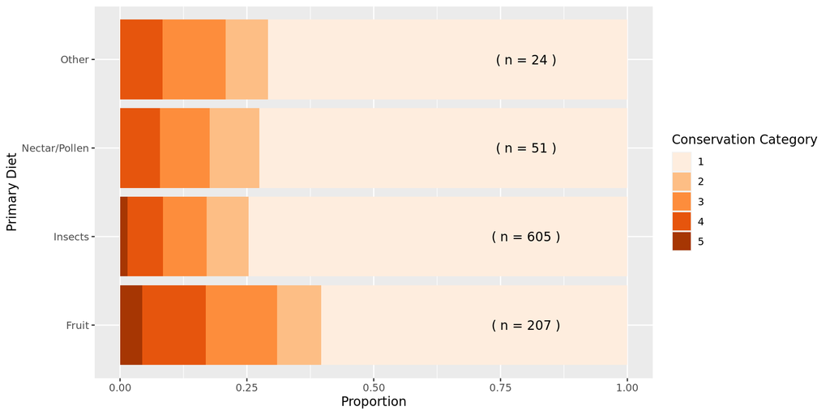

```r
size.df$x = diets
size.df$y=0.8

ggplot(subsettable,aes(x=Simple.Primary.diet))+
  geom_bar(aes(fill=factor(Conservation.category.numeric)),position="fill")+
  scale_fill_brewer(palette=7)+
  ylab("Proportion")+
  xlab("Primary Diet")+
  geom_text(data=size.df,aes(label=sizes,y=y,x=x))+
  labs(fill="Conservation Category")+
  coord_flip()
```

## 11.3 Category by Island/mainland

```r
subsettable = with(modelVariables,data.frame(Island.mainland.classification,Conservation.category.numeric))
subsettable=subsettable[complete.cases(subsettable),]
tab = addmargins(table(subsettable))

kable(tab)
```

|  | 1 | 2 | 3 | 4 | 5 | Sum |
| --- | --- | --- | --- | --- | --- | --- |
| Island | 146 | 34 | 54 | 46 | 14 | 294 |
| Mainland | 465 | 36 | 34 | 26 | 3 | 564 |
| Sum | 611 | 70 | 88 | 72 | 17 | 858 |

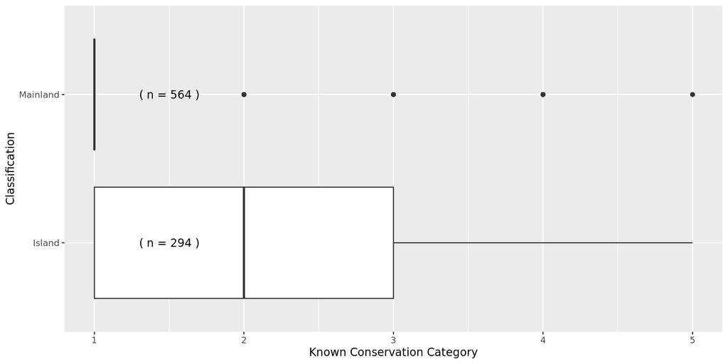

```r
p=nrow(tab)-1
classification = rownames(tab);classification=classification[1:p]#removes "sum"
sizes = paste( "( n =",tab[1:p,ncol(tab)],")")

size.df = data.frame(
  sizes=sizes,
  x=seq_len(p),
  y=rep(1.5,p)
)


ggplot(subsettable,aes(x=Island.mainland.classification,y=Conservation.category.numeric))+
  geom_boxplot()+xlab("Classification")+ylab("Known Conservation Category")+
  geom_text(data=size.df,aes(label=sizes,y=y,x=x))+
  coord_flip()
```

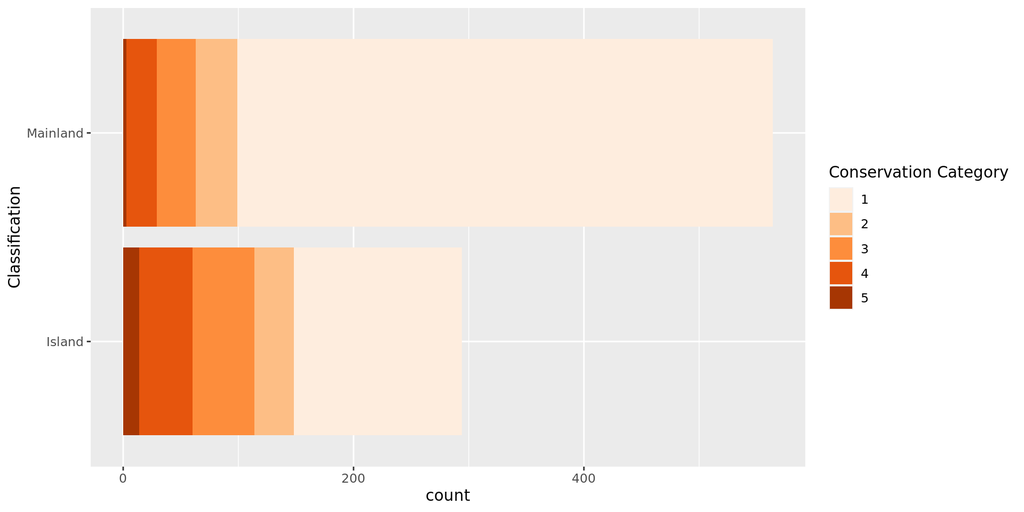

```r
#boxplot(modelVariables$Conservation.category.numeric~modelVariables$Habitats)

ggplot(subsettable,aes(x=Island.mainland.classification))+
  geom_bar(aes(fill=factor(Conservation.category.numeric)))+
  scale_fill_brewer(palette=7)+
  labs(fill="Conservation Category")+
  xlab("Classification")+
  coord_flip()
```

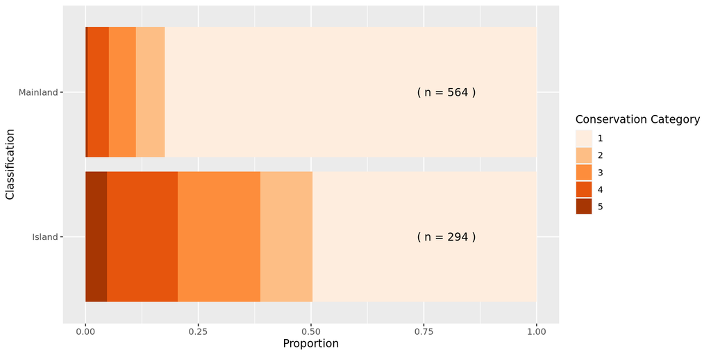

```r
size.df$x = classification
size.df$y=0.8

ggplot(subsettable,aes(x=Island.mainland.classification))+
  geom_bar(aes(fill=factor(Conservation.category.numeric)),position="fill")+
  scale_fill_brewer(palette=7)+
  ylab("Proportion")+
  xlab("Classification")+
  geom_text(data=size.df,aes(label=sizes,y=y,x=x))+
  labs(fill="Conservation Category")+
  coord_flip()
```

## 11.4 Category by elevation

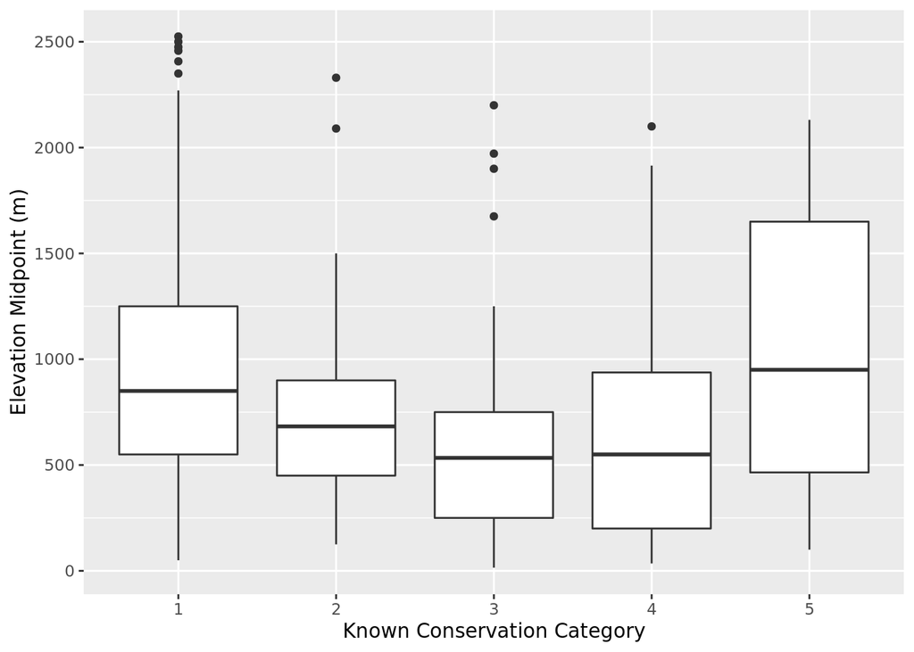

```r
subsettable = with(modelVariables,data.frame(Altitude.mid.m,Conservation.category.numeric))
subsettable=subsettable[complete.cases(subsettable),]
tab = addmargins(table(subsettable))



p=nrow(tab)-1
classification = rownames(tab);classification=classification[1:p]#removes "sum"
sizes = paste( "( n =",tab[1:p,ncol(tab)],")")

size.df = data.frame(
  sizes=sizes,
  x=seq_len(p),
  y=rep(1.5,p)
)



#kable(tab)

ggplot(subsettable,aes(x=Altitude.mid.m,y=factor(Conservation.category.numeric)))+
   geom_boxplot()+xlab("Elevation Midpoint (m)")+ylab("Known Conservation Category")+
  coord_flip()
```

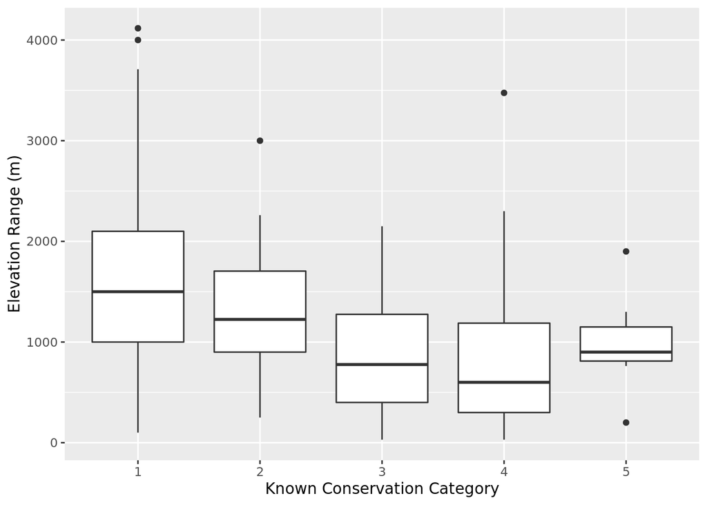

```r
#boxplot(modelVariables$Conservation.category.numeric~modelVariables$Habitats)









subsettable = with(modelVariables,data.frame(Altitude.range.m,Conservation.category.numeric))
subsettable=subsettable[complete.cases(subsettable),]
tab = addmargins(table(subsettable))



p=nrow(tab)-1
classification = rownames(tab);classification=classification[1:p]#removes "sum"
sizes = paste( "( n =",tab[1:p,ncol(tab)],")")

size.df = data.frame(
  sizes=sizes,
  x=seq_len(p),
  y=rep(1.5,p)
)




ggplot(subsettable,aes(x=Altitude.range.m,y=factor(Conservation.category.numeric)))+
   geom_boxplot()+xlab("Elevation Range (m)")+ylab("Known Conservation Category")+
  coord_flip()
```

```r
#boxplot(modelVariables$Conservation.category.numeric~modelVariables$Habitats)
```

## 11.5 Category by Area

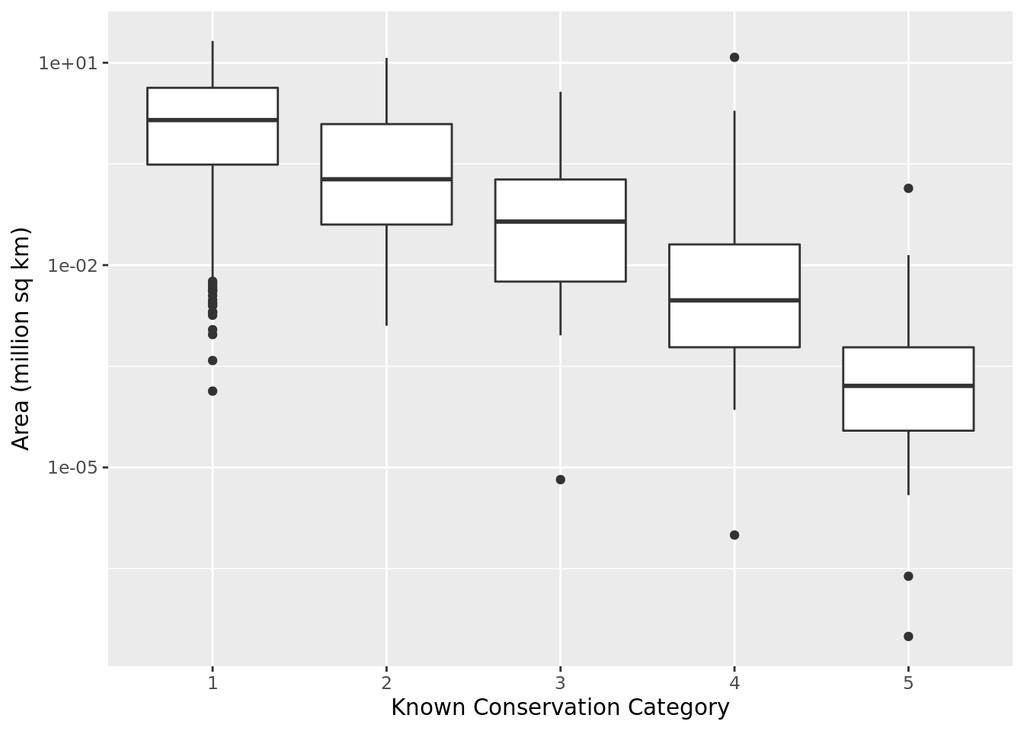

```r
subsettable = with(modelVariables,data.frame(Area.mkm,Conservation.category.numeric))
subsettable=subsettable[complete.cases(subsettable),]
tab = addmargins(table(subsettable))



p=nrow(tab)-1
classification = rownames(tab);classification=classification[1:p]#removes "sum"
sizes = paste( "( n =",tab[1:p,ncol(tab)],")")

size.df = data.frame(
  sizes=sizes,
  x=seq_len(p),
  y=rep(1.5,p)
)



#kable(tab)

ggplot(subsettable,aes(x=Area.mkm,y=factor(Conservation.category.numeric)))+
   geom_boxplot()+xlab("Area (million sq km)")+ylab("Known Conservation Category")+scale_x_log10()+coord_flip()
```

```r
#boxplot(modelVariables$Conservation.category.numeric~modelVariables$Habitats)
```

## 11.6 Category by Max temp

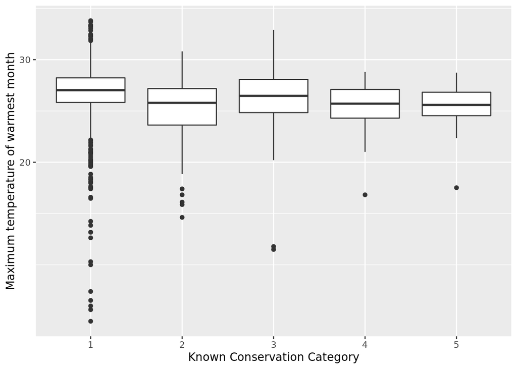

```r
subsettable = with(modelVariables,data.frame(Max.temp.warmest.month,Conservation.category.numeric))
subsettable[,1]=subsettable[,1]/12
subsettable=subsettable[complete.cases(subsettable),]
tab = addmargins(table(subsettable))


p=nrow(tab)-1
classification = rownames(tab);classification=classification[1:p]#removes "sum"
sizes = paste( "( n =",tab[1:p,ncol(tab)],")")

size.df = data.frame(
  sizes=sizes,
  x=seq_len(p),
  y=rep(1.5,p)
)



#kable(tab)

ggplot(subsettable,aes(x=Max.temp.warmest.month,y=factor(Conservation.category.numeric)))+
   geom_boxplot()+xlab("Maximum temperature of warmest month")+ylab("Known Conservation Category")+scale_x_log10()+coord_flip()
```

```r
#boxplot(modelVariables$Conservation.category.numeric~modelVariables$Habitats)
```

## 11.7 Category by Weight

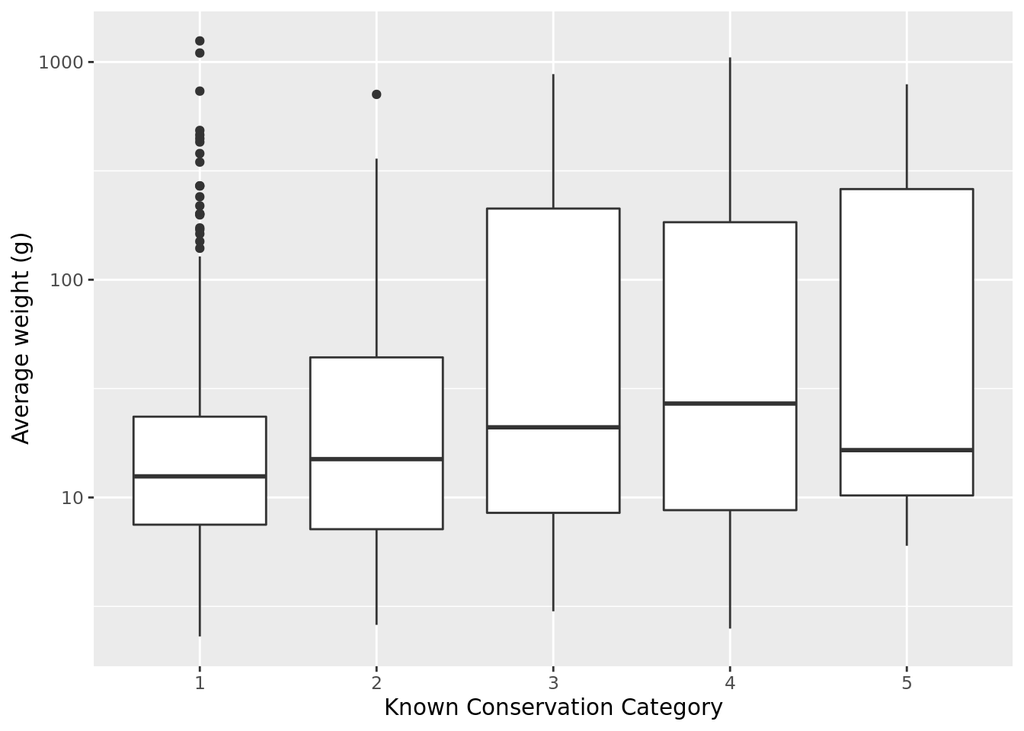

```r
subsettable = with(modelVariables,data.frame(weight.avg.g,Conservation.category.numeric))
subsettable=subsettable[complete.cases(subsettable),]
tab = addmargins(table(subsettable))



p=nrow(tab)-1
classification = rownames(tab);classification=classification[1:p]#removes "sum"
sizes = paste( "( n =",tab[1:p,ncol(tab)],")")

size.df = data.frame(
  sizes=sizes,
  x=seq_len(p),
  y=rep(1.5,p)
)




ggplot(subsettable,aes(x=weight.avg.g,y=factor(Conservation.category.numeric)))+
   geom_boxplot()+xlab("Average weight (g)")+ylab("Known Conservation Category")+
  scale_x_log10()+coord_flip()
```

```r
#boxplot(modelVariables$Conservation.category.numeric~modelVariables$Habitats)
```

# 12 Tables

Tables of the highest fitted conservation statuses

### 12.0.1 By highest median GLS estimates

```r
imputedEstimates[order(imputedEstimates$glsestimate,decreasing=T),]
```

```
##                               glsestimate actual
## Pteropus_melanopogon          3.466282968      4
## Pteropus_livingstonii         3.430933510      5
## Pteralopex_flanneryi          3.357969039      5
## Acerodon_jubatus              3.349146157      4
## Pteropus_howensis             3.322517699      5
## Pteropus_speciosus            3.255125860   <NA>
## Pteropus_neohibernicus        3.253482239      1
## Pteropus_conspicillatus       3.252830104      4
## Pteropus_voeltzkowi           3.244976637      3
## Alionycteris_paucidentata     3.186832452      1
## Rousettus_linduensis          3.184696477   <NA>
## Pteropus_caniceps             3.158346692      3
## Pteropus_mariannus            3.140868857      4
## Pteropus_vampyrus             3.133537058      4
## Pteralopex_pulchra            3.131624234      5
## Pteropus_rufus                3.057881546      3
## Rhinolophus_willardi          3.026402351      4
## Nyctophilus_microdon          3.015390551      1
## Pteropus_ocularis             3.014380077      3
## Nyctimene_minutus             2.976279808      3
## Hypsugo_lanzai                2.960242729      4
## Pteropus_rodricensis          2.930354102      4
## Pteropus_niger                2.925803420      4
## Pteropus_griseus              2.923907607      3
## Pteropus_aldabrensis          2.900749743      4
## Pteropus_pelewensis           2.899535740      3
## Kerivoula_agnella             2.899232695      4
## Pteropus_pohlei               2.898932796      3
## Pteropus_pselaphon            2.872972684      4
## Neoromicia_malagasyensis      2.860600006      3
## Pteropus_keyensis             2.850876817   <NA>
## Phyllonycteris_aphylla        2.841766884      5
## Dyacopterus_rickarti          2.832507714      4
## Plecotus_sacrimontis          2.830856031      1
## Rhinolophus_madurensis        2.811087633      3
## Neopteryx_frosti              2.798694811      4
## Pteropus_rennelli             2.780092588      4
## Pteropus_aruensis             2.776434364      5
## Glischropus_javanus           2.770105692   <NA>
```

[output cut: 987 more lines]

```
## Lichonycteris_obscura         0.022976545      1
## Scleronycteris_ega            0.016932580   <NA>
## Eptesicus_fuscus              0.015322491      1
## Choeroniscus_godmani          0.012418922      1
## Lionycteris_spurrelli        -0.007014505      1
## Nyctinomops_macrotis         -0.015621447      1
## Myotis_daubentonii           -0.021786602      1
## Phyllostomus_discolor        -0.029902886      1
## Saccopteryx_bilineata        -0.037334475      1
## Rhinolophus_ferrumequinum    -0.063046014      1
## Macroglossus_sobrinus        -0.065505141      1
## Molossus_molossus            -0.260054308      1
## Anoura_latidens              -0.285705237      1
## Vespertilio_murinus          -0.423940451      1
## Desmodus_rotundus            -0.573779510      1
```

### 12.0.2 By actual conservation status

```r
imputedEstimates[order(imputedEstimates$actual,decreasing=T),]
```

```
##                               glsestimate actual
## Coleura_seychellensis         2.384834316      5
## Hipposideros_hypophyllus      1.882945558      5
## Hipposideros_lamottei         1.562638505      5
## Eudiscoderma_thongareeae      2.351476880      5
## Phyllonycteris_aphylla        2.841766884      5
## Aproteles_bulmerae            2.587715753      5
## Dobsonia_chapmani             2.229863285      5
## Mirimiri_acrodonta            2.390694261      5
## Pteralopex_flanneryi          3.357969039      5
## Pteralopex_pulchra            3.131624234      5
## Pteropus_aruensis             2.776434364      5
## Pteropus_howensis             3.322517699      5
## Pteropus_livingstonii         3.430933510      5
## Rhinolophus_hilli             2.758868476      5
## Chalinolobus_tuberculatus     2.339357658      5
## Myotis_yanbarensis            2.432400235      5
## Nyctophilus_nebulosus         2.405053355      5
## Pharotis_imogene              2.525987949      5
## Emballonura_semicaudata       1.894058791      4
## Saccopteryx_antioquensis      2.018973270      4
## Taphozous_hildegardeae        1.979124990      4
## Hipposideros_coxi             2.378269240      4
## Hipposideros_curtus           1.499586734      4
## Hipposideros_demissus         2.601363450      4
## Hipposideros_sorenseni        1.897967559      4
## Hipposideros_turpis           2.372150727      4
## Miniopterus_fuscus            1.958084345      4
## Miniopterus_robustior         2.564269890      4
## Chaerephon_bregullae          2.443668525      4
## Chaerephon_solomonis          2.689546998      4
## Chaerephon_tomensis           2.119733390      4
## Molossops_aequatorianus       1.691297602      4
## Mormopterus_acetabulosus      2.553151666      4
## Tadarida_latouchei            1.551632688      4
## Tomopeas_ravus                1.435946431      4
## Pteronotus_paraguanensis      2.434641118      4
## Chiroderma_improvisum         2.342601372      4
## Leptonycteris_nivalis         0.986749297      4
## Lonchophylla_bokermanni       1.152665653      4
```

[output cut: 987 more lines]

```
## Nyctophilus_heran             2.281201947   <NA>
## Nyctophilus_shirleyae         2.039272400   <NA>
## Pipistrellus_aero             1.837312687   <NA>
## Pipistrellus_inexspectatus    0.927905401   <NA>
## Pipistrellus_permixtus        1.299974266   <NA>
## Pipistrellus_raceyi           2.337145529   <NA>
## Plecotus_balensis             2.465423695   <NA>
## Plecotus_christii             1.001131970   <NA>
## Rhogeessa_hussoni             1.734637827   <NA>
## Rhogeessa_menchuae            1.521149641   <NA>
## Scotoecus_albofuscus          0.675754077   <NA>
## Scotophilus_borbonicus        2.329151002   <NA>
## Scotophilus_celebensis        2.025422475   <NA>
## Scotophilus_nucella           1.386495996   <NA>
## Tylonycteris_pygmaeus         1.410739534   <NA>
```

# 13 Continuous variables by conservation status

## 13.1 By area

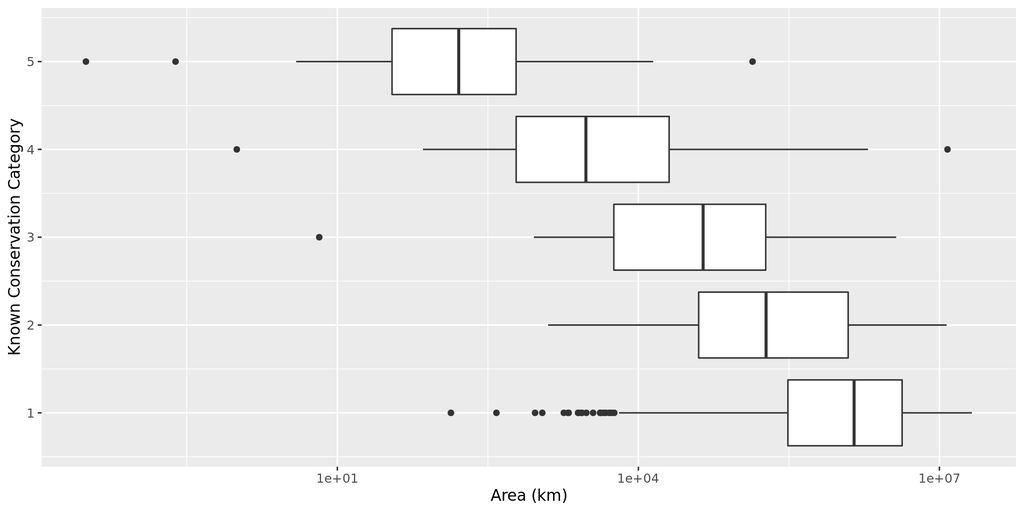

```r
subsettable = with(name.data,data.frame(Area.km,Conservation.category.numeric))
subsettable=subsettable[complete.cases(subsettable),]


ggplot(subsettable,aes(x=Area.km,y=Conservation.category.numeric,group=Conservation.category.numeric))+
  geom_boxplot()+xlab("Area (km)")+ylab("Known Conservation Category")+scale_x_continuous(trans='log10')
```

```r
  # geom_text(data=size.df,aes(label=sizes,y=y,x=x))+
  #coord_flip()
#boxplot(modelVariables$Conservation.category.numeric~modelVariables$Habitats)
```

## 13.2 By temperature

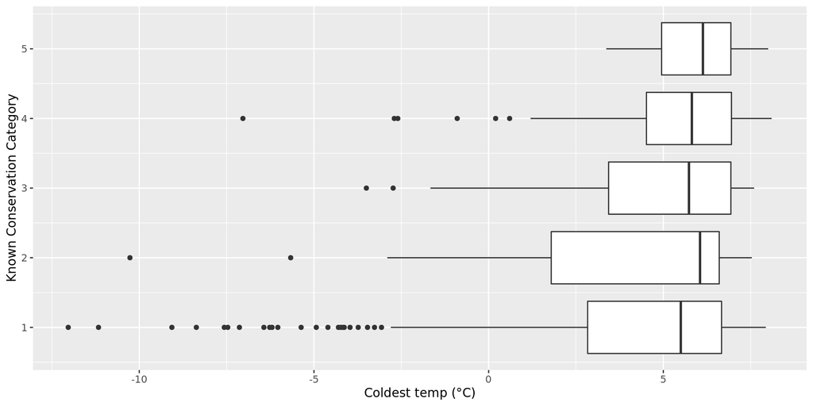

```r
subsettable = with(name.data,data.frame(Min.temp.coldest.month,Conservation.category.numeric))
subsettable=subsettable[complete.cases(subsettable),]
subsettable[,1]=subsettable[,1]/30


ggplot(subsettable,aes(x=Min.temp.coldest.month,y=Conservation.category.numeric,group=Conservation.category.numeric))+
  geom_boxplot()+xlab("Coldest temp (°C)")+ylab("Known Conservation Category")#+scale_x_continuous(trans='log10')
```

```r
  # geom_text(data=size.df,aes(label=sizes,y=y,x=x))+
  #coord_flip()
#boxplot(modelVariables$Conservation.category.numeric~modelVariables$Habitats)
```

# 14 TypeI vs type II analsyis

In the code below, we try to estimate if a species is high-risk (positive) or low-risk (negative). We define high-risk as being category 4 or 5.

The type I error rate is the proportion of low-risk species being called high risk (accidental flags).

The type II error rate is the proportion of high-risk species being called low-risk (missing stuff).

I think we can approach it this way: decide what type II error rate we think is reasonable, and look to see if the corresponding type I error rate is acceptable..

```r
obtain2x2 = function(k,residuals,fitted){ #k is the threshold
  precisionrecall = mcsapp(1:length(imputedModelsGLS),function(i){

    predictions  = fitted                  #   =yhat
    actualvalues = residuals+predictions   #  y=r+yhat

    predictedrisk = predictions >= k
    actuallyatrisk= actualvalues>=4

    tp = mean( predictedrisk &  actuallyatrisk)
    tn = mean(!predictedrisk & !actuallyatrisk)
    fp = mean( predictedrisk & !actuallyatrisk)
    fn = mean(!predictedrisk &  actuallyatrisk)

    c(tp=tp,tn=tn,fp=fp,fn=fn)
  })
  rowMeans(precisionrecall)
}




geterrors = function(dat){
  dat=as.data.frame(dat)

  tpr = sensitivity = with(dat,tp/(tp+fn))
  tnr = specificity = with(dat,tn/(tn+fp))
  fpr =               with(dat,fp/(fp+tn))

  type1 = fpr
  type2 = with(dat,fn/(tp+fn))
  power = 1-type2

  ord = order(tpr)
#  tpr=tpr[order(tpr)]
#  tnr=tnr[order(tnr)]
  data.frame(type1=type1,type2=type2)
}

phylosig(bat.tree,name.data$Conservation.category.numeric,method="K")
```

```
## [1] "x has no names; assuming x is in the same order as tree$tip.label"
## [1] "some data in x given as 'NA', dropping corresponding species from tree"
```

```
##
## Phylogenetic signal K : 0.0561082
```

```r
phylosig(bat.tree,name.data$Conservation.category.numeric,method="lambda")
```

```
## [1] "x has no names; assuming x is in the same order as tree$tip.label"
## [1] "some data in x given as 'NA', dropping corresponding species from tree"
```

```
##
## Phylogenetic signal lambda : 0.125926
## logL(lambda) : -1310.6
```

```r
thresholds = seq(0,5,.05)

prs = mcsapp(thresholds,
             obtain2x2,
             residuals=imputedGLS.residuals,
             fitted=imputedGLS.fitted) |>
  t() |> as.data.frame()


fitted = imputedGLS.fitted
actual = fitted+imputedGLS.residuals

fitted=fitted[knownSpecies,]
actual=actual[knownSpecies,]


require(pROC)
```

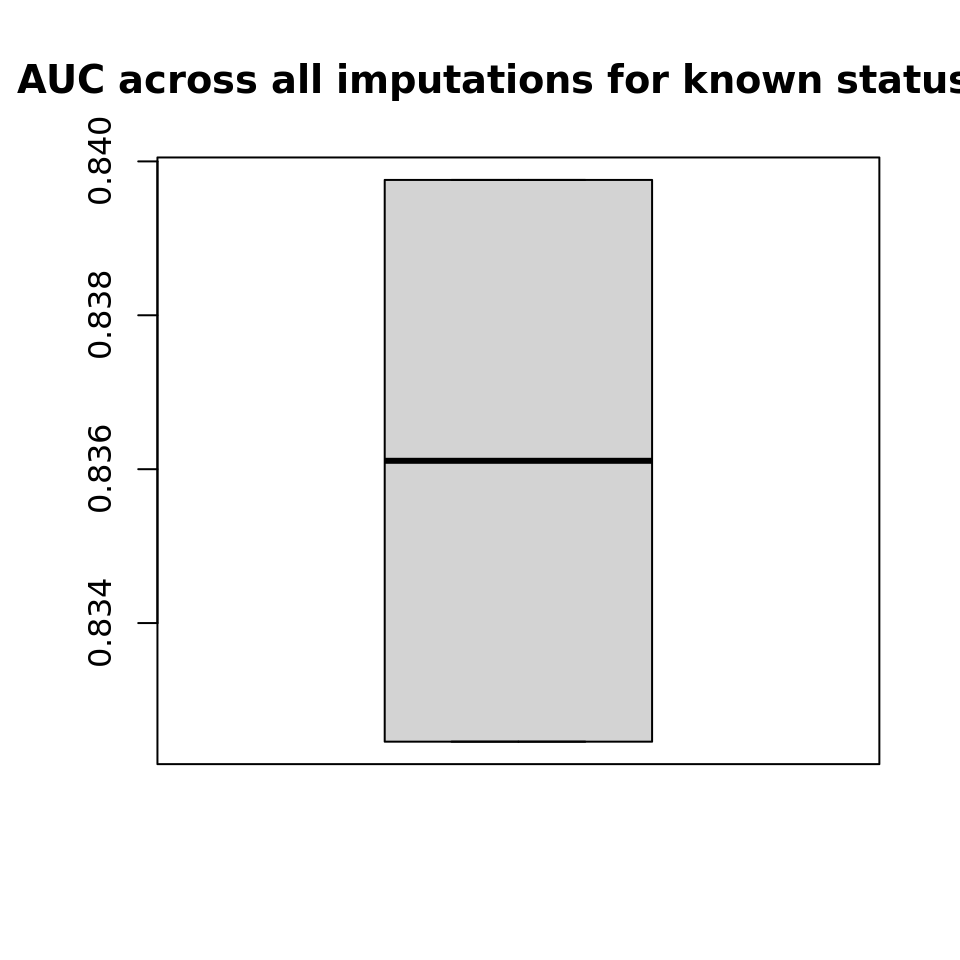

```r
getroc = function(i) roc(actual[,i]>=4,fitted[,i],quiet=T)
getauc = function(roc)roc$auc[1]

rocs = mclapp(1:ncol(actual),getroc)
aucs = mcsapp(rocs,getauc)
boxplot(aucs,main="AUC across all imputations for known statuses",horizontal=F)
```

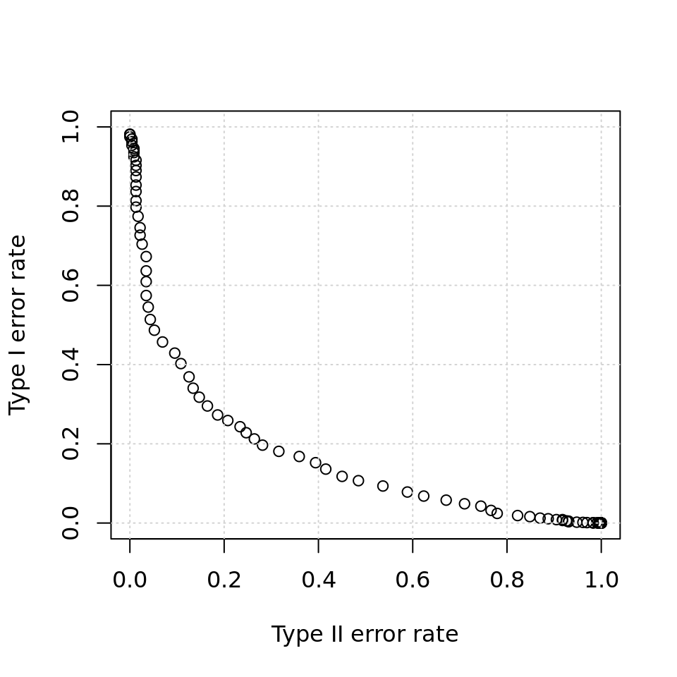

```r
#print(dim(imputedGLS.fitted))

#via midpoint riemann sum



prsvalues = geterrors(prs)




#power = 1-prsvalues$type2
#prsvalues = data.frame(prsvalues,power)



plot(prsvalues$type2,prsvalues$type1,xlim=c(0,1),ylim=c(0,1),xlab="Type II error rate",lty=1,ylab="Type I error rate")
grid()
```

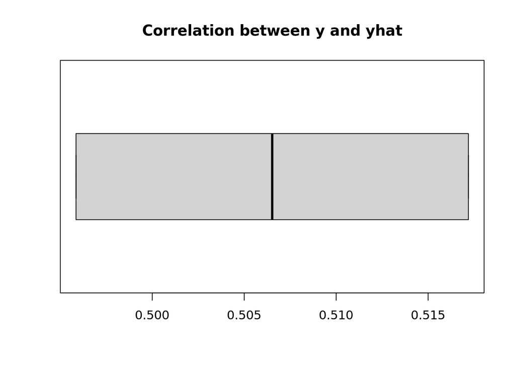

```r
cors = apply(imputedGLS.fitted,2,function(fits)
  cor(fits[knownSpecies],actualStatus[knownSpecies])
  )
boxplot(cors,horizontal=T,main="Correlation between y and yhat")
```

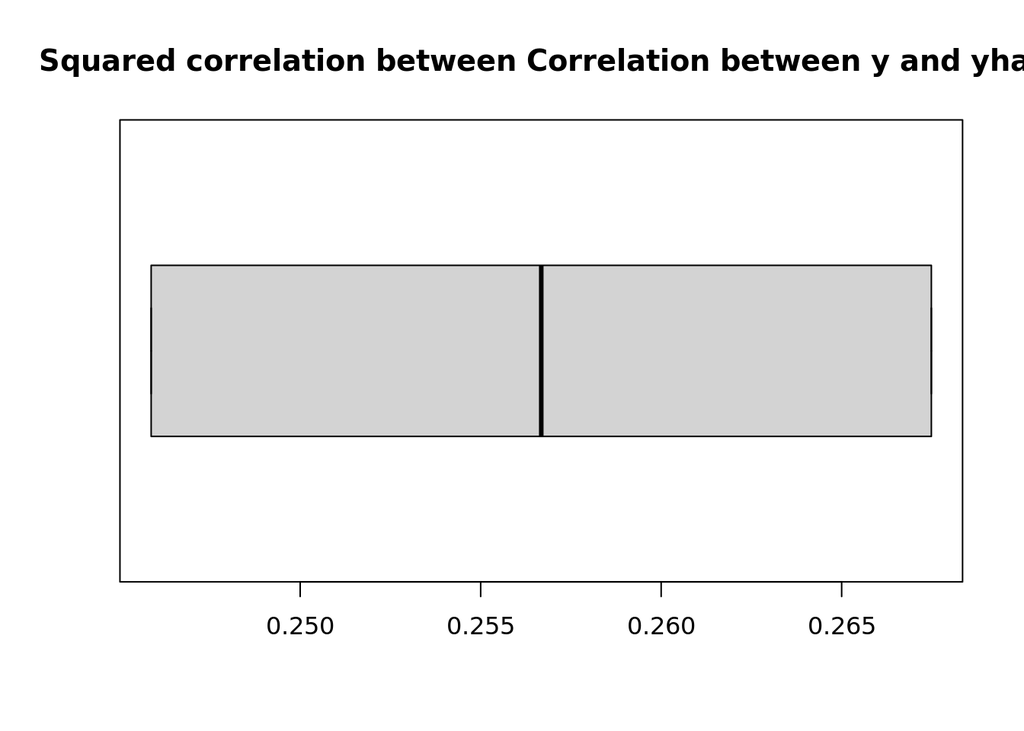

```r
boxplot(cors^2,horizontal=T,main="Squared correlation between Correlation between y and yhat")
```

```r
mlsmodels = function(new.traits.i){
  Species = rownames(new.traits.i)
  new.traits.i=data.frame(Species=rownames(new.traits.i),new.traits.i)
  Full.Models <-lm(Conservation.category.numeric~
                      collapsed.Habitats +
                      Simple.Primary.diet +
                      weight.avg.g +
                      Island.mainland.classification +
                      Min.temp.coldest.month +
                      Annual.precip. +
                      Area.mkm,
                    data = new.traits.i)
}

mlsmodels = function(new.traits.i){
  Species = rownames(new.traits.i)
  new.traits.i=data.frame(Species=rownames(new.traits.i),new.traits.i)
  Full.Models <-lm(Conservation.category.numeric~
                      collapsed.Habitats +
                      Simple.Primary.diet +
                      weight.avg.g +
                      Island.mainland.classification +
                      Min.temp.coldest.month +
                      Annual.precip. +
                      Area.mkm,
                    data = new.traits.i)
}


require(parallel)
#mlsmodels = mclapply(new.traits.list,mlsmodels,mc.cores=detectCores())
```

# 15 Comparison with complete data

```r
#completegls = gls(Conservation.category.numeric~.,
                  #   correlation = corBrownian(phy = bat.tree,form=~Species),
                  #   data = modelVariables,
                  #   method = "ML",
                  # na.action=na.omit
                  # )


completelm = lm(Conservation.category.numeric~ .,
                    data = modelVariables)



yhat = completelm$fitted.values
y    = yhat + completelm$residuals
lmr2all=cor(y,yhat)^2


# yhat = completegls$fitted
# y    = yhat + completegls$residuals
# glsr2all=cor(y,yhat)^2
```

## 15.1 How much each variable explains by itself

```r
modmatrix = modelVariables
  # with(name.data,data.frame(Conservation.category.numeric,
  #                     collapsed.Habitats,
  #                     Simple.Primary.diet,
  #                     weight.avg.g,
  #                     Island.mainland.classification,
  #                     Min.temp.coldest.month,
  #                     Annual.precip.,
  #                     Area.mkm))

r2value=function(i){
  df = modmatrix[,c(1,i)]
  mod = lm(Conservation.category.numeric~.,data=df)
  yhat = mod$fitted.values
  y    = yhat + mod$residuals
  round(cor(y,yhat)^2*100/lmr2all)
}

cols = 2:ncol(modmatrix)
explained = data.frame(names(modmatrix[,cols]),sapply(cols,r2value))
names(explained)=c("Var","Percent")
```

```r
print(explained)
```

```
##                              Var Percent
## 1             collapsed.Habitats       8
## 2                 Altitude.mid.m      11
## 3               Altitude.range.m      37
## 4         Max.temp.warmest.month       5
## 5            Simple.Primary.diet       8
## 6                   weight.avg.g      36
## 7 Island.mainland.classification      41
## 8                 Annual.precip.       3
## 9                       Area.mkm      34
```